# Introduction to statistical modelling

Shane Blowes

28 January 2021

## Statistical modelling

Short introduction to statistical models:

- linear models
- generalised linear models
- non-linear models (e.g., basis expansion, generalised additive models, LOESS)

## Linear models

Linear models take the form:
$$y_i = \beta x_i + \epsilon_i,$$
where $y_i$ is the observed *response* variable (here species richness), $\beta$ is a vector of estimated (unknown) parameters, $x_i$ are (known) covariates (can be continuous or categorical *predictors*), and $\epsilon_i$ are random variables (mutually independent with zero mean and variance, $\sigma^2$)

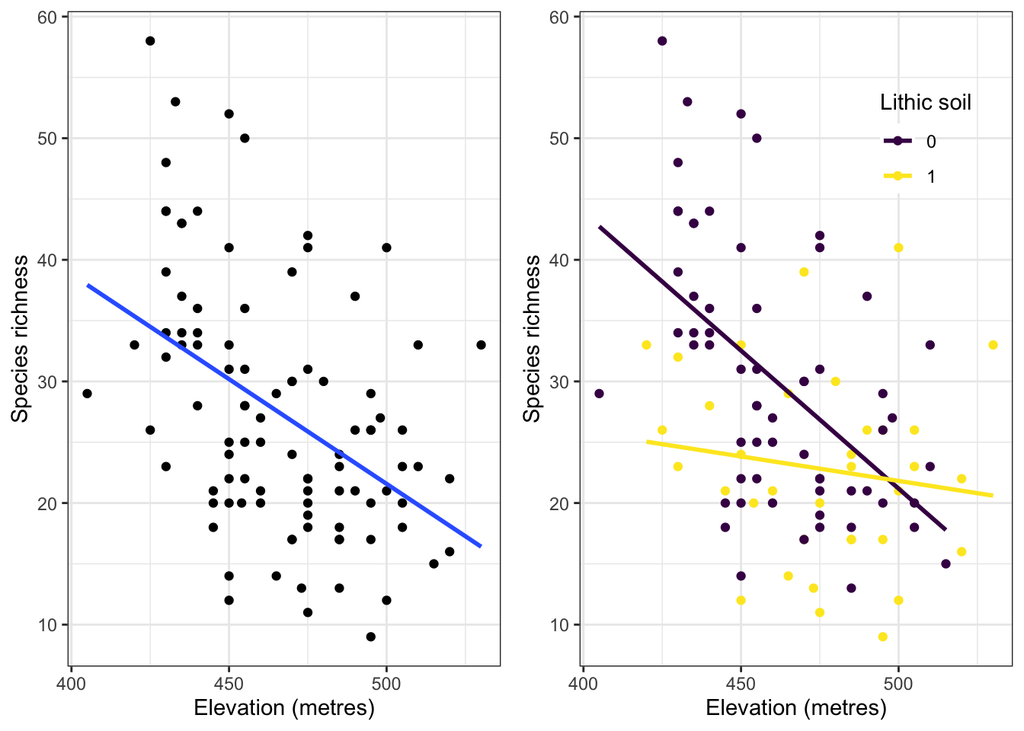

### All statistical modelling involves a trade-off between *underfitting* and *overfitting*.

- *Underfitting* results in poor prediction by learning too little from the data
- *Overfitting* results in poor prediction by learning too much from the data

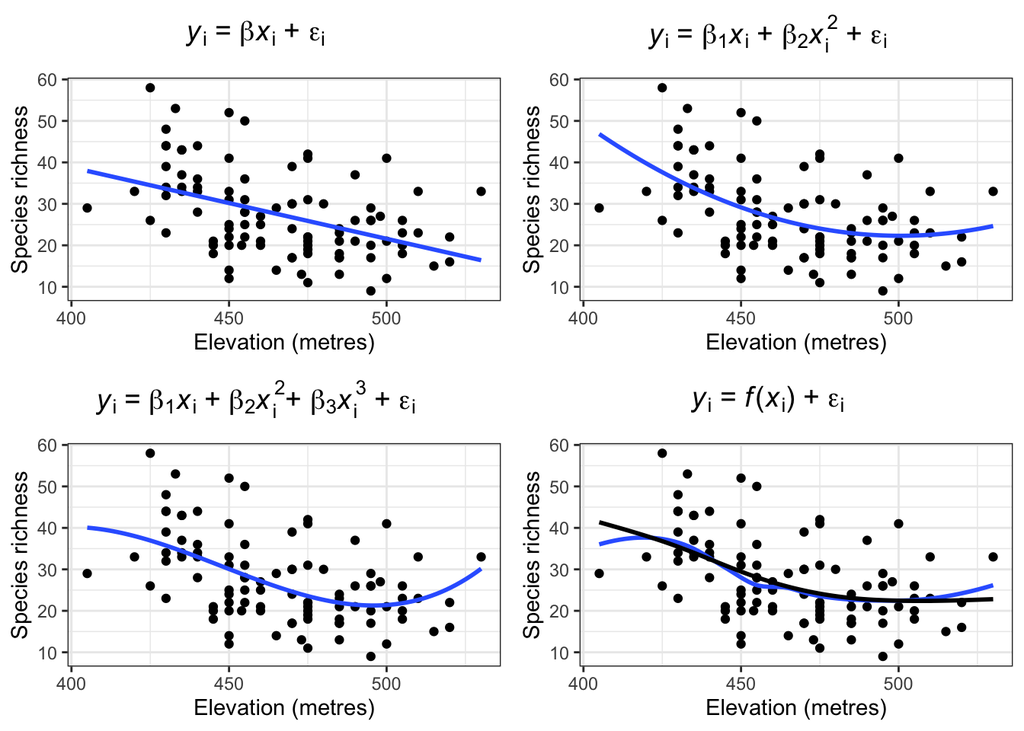

## Generalized linear models

Extend linear models to allow for response distributions other than normal. Now, our observed values, $Y_i$, are drawn from the a distribution of the so-called exponential family (e.g., Bernoulli, normal, gamma, exponential, Poisson, beta). The basic structure remains familiar, but with the addition of a 'link' function.

$E(Y_i)=\mu_i$, and $var(Y_i)=\sigma^2$

$g(\mu_i)=\beta X_i$, where $g()$ is a link function.

For example, all the models above assume normally distributed error, so

$Y_i$ ~ $N(\mu_i, \sigma^2)$

$E(Y_i)=\mu_i$, and $var(Y_i)=\sigma^2$

$g(\mu_i)=\beta X_i$, where $g()$ is referred to as the identity link function.

Alternatively, as our estimate of species richness arises from a *count* process, we could formulate the model using the poisson distribution

$Y_i$ ~ $poisson(\mu_i)$

$E(Y_i)=\mu_i$, and $var(Y_i)=\mu_i$

$log(\mu_i)=\beta X_i$, and $g()$ is now the log link function.

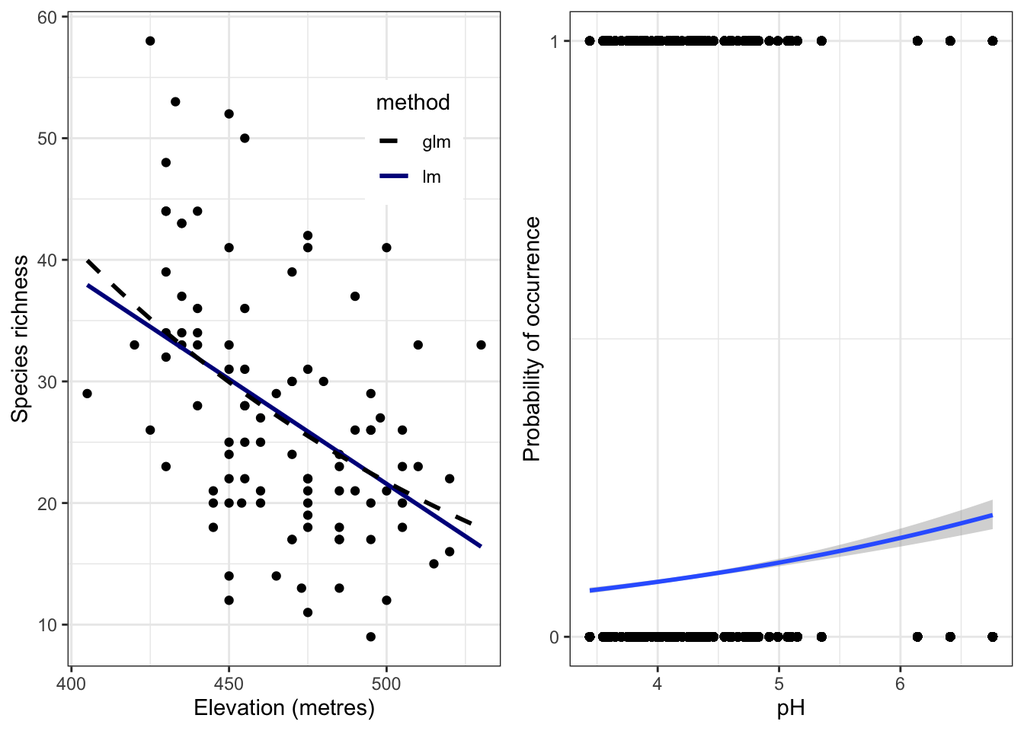